# STAT 340: Lecture 1 - Introduction

## STAT 340 - Introduction

**Applied Methods in Statistics**

**Lecturer:** Ass. Prof. Aliaksandr Hubin, KBM  
**Assistant Teacher:** Elias Bye Rossetnes

**Date:** 03.02.2025  
**Institution:** NMBU - Norges miljø- og biovitenskapelige universitet

## Course Teachers

## Lecturer

**Ass. Prof. Aliaksandr Hubin, KBM** - Office: M252 - Old diary science building (Meieribygningen)

- Email: aliaksandr.hubin@nmbu.no

## Assistant Teacher

**Elias Bye Rossetnes**

## Class Schedule

## Lectures

- **When:** Tuesdays 14:15–16:00
- **Where:** Room T330
- **First Lecture:** Feb 3

## Exercises (individual work)

- **When:** Thursdays 14:15–16:00
- **Where:** Room BT3A10
- **First Session:** Feb 5

## Practical Information

## Mandatory Activity

- **Four compulsory quiz assignments**
- You can be released from a quiz by answering 10 questions correctly during lectures (no penalty for wrong answers).
- This will work even after failing a quiz.

## Exam

- **Format:** Multiple choice (100%)
- **Grading:** A–E or Not Passed
- **Allowed:** All calculators and specified **written** aids
- **Date & Time:** **May 18, 09:00–12:00**
- **Important:** No date changes possible

## Learning Activities (Weekly)

- **Lectures:** 2 hours
- **Group Exercises:** 2 hours
- **Individual Work:** 2 hours

**Total:** 6 hours per week

## Assumed Background: STAT 100

Students should be familiar with:

- Basic rules of probability (we shall repeat that today)
- Common probability distributions (we shall repeat that today):
  - Binomial
  - Gaussian (Normal)
  - Student’s t
  - Fisher’s F
- Hypothesis testing:
  - One-sample t-tests
  - Two-sample t-tests
  - Paired sample t-tests
- One-way Analysis of Variance (ANOVA)
- Simple linear regression (one predictor variable)
- Contingency tables

## Software & Data

## Software

- **R Studio** for R programming language
- Practical analysis using various statistical methods
- Theoretical and practical interpretation of results
- (Other software may be used if methods are available)

## Data

- Mainly R library: **BIAS.data** (GitHub) https://github.com/thoree/BIAS.data

## STAT 340 Course Content

## Main Topics

1. **Introduction to R and RStudio**
   - Practical analysis using various statistical methods
2. **Multiple Linear Regression**
3. **Multivariate Analysis**
   - Principal Component Analysis (PCA)
4. **Classification Methods**
5. **Clustering Methods**
6. **Generalized Linear Models (GLM)**
   - Binomial/Bernoulli (logistic) regression
   - Poisson regression
   - Mixed models (GLMM): Random effects, repeated measurements

## Required Learning Resources

## Primary Materials

- **Lecture presentations** (provided)
- **All exercises** (provided)

## Recommended Textbooks (available online)

**Main Reference:** - **R Book:** Michael J Crawley, Wiley (2nd ed.) - Chapters: 1–9 (as needed), 10–13, 17, 19, 25 - Freely available https://www.cs.upc.edu/~robert/teaching/estadistica/TheRBook.pdf

**Supplementary (mathematical details):** - **ISL:** James et al. ``An Introduction to Statistical Learning’’ - Chapters: 1–4, 6.1, 7.1, 10 - Freely available https://www.statlearning.com

## Typical Week Structure

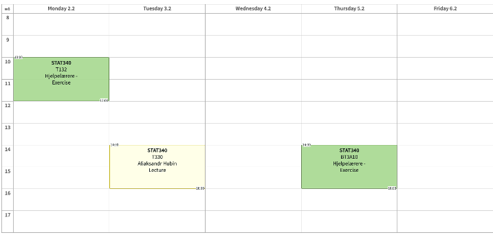

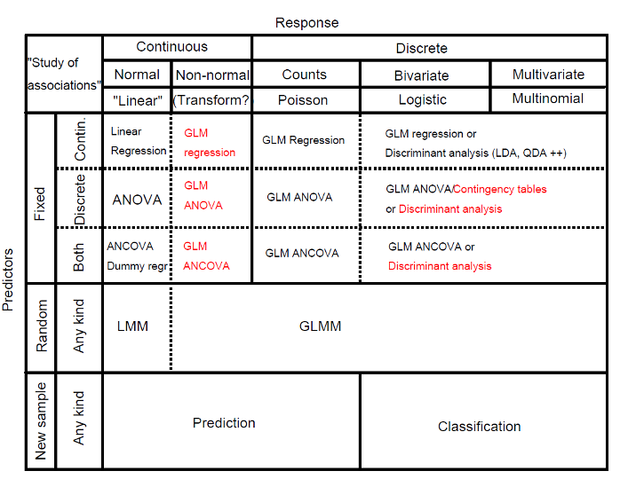

## Reflection Activity

**Turn to your neighbour(s) and discuss:**

- Do you know what kind of **data** you will be dealing with in your work?
- Do you have any idea what **association studies** or **methods** are relevant for your research?
- Are they mentioned in the table in the previous page?

## Now, Let’s Begin!

## Lecture 1, Part B: Review of Basic Statistics

We’ll start with basics of **probability theory** - the mathematical foundation for **uncertainty** and **statistical inference**.

## Part 0: Foundations of Probability

## Setting Up a Random Experiment

Before studying random variables, we need to define randomness formally.

**A probability setup has three components:**

1. **Sample space** \(\Omega\): all possible outcomes
   - *Discrete:* Coin flip: \(\Omega = \{\text{H}, \text{T}\}\)
   - *Continuous:* Adult height: \(\Omega = [120, 250] \text{ cm}\)
2. **Events** \(\mathcal{F}\): subsets of outcomes we observe
   - *Discrete:* \(\{\text{H}\}\) = ``heads’’
   - *Continuous:* \(\{h : 175.3\}\)
3. **Probabilities** \(P\): assigns to events a number in \([0,1]\)
   - *Discrete:* \(P(\text{H}) = 0.5\)
   - *Continuous:* \(P(160 \leq h \leq 180) = 0.68\)

Together: \((\Omega, \mathcal{F}, P)\) is a **probability space**.

## Andrey Kolmogorov (1903–1987)

- Established the **foundations of probability** (1933)
- Formalized the concept of probability space \((\Omega, \mathcal{F}, P)\).

**Kolmogorov’s Axioms**:

1. \(P(\Omega) = 1\) (certainty has probability 1)
2. \(P(A) \geq 0\) for all outcomes \(A\) (non-negativity)
3. Countable additivity: If \(A_1, A_2, \ldots\) are disjoint events, then \(P(\bigcup_i A_i) = \sum_i P(A_i)\)

## Part 1: Random Variables

## What is a Random Variable?

A **random variable** is a function that assigns a numeric value to each outcome in the sample space. Maps from experiment sample space to a real space.

**Why?** Numbers let us compute statistics: averages, spreads, and patterns.

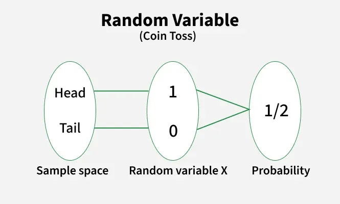

**Example:** Coin flip outcome \(\to\) Number: - Heads \(\to Y = 1\) - Tails \(\to Y = 0\)

## Discrete vs. Continuous Random Variables

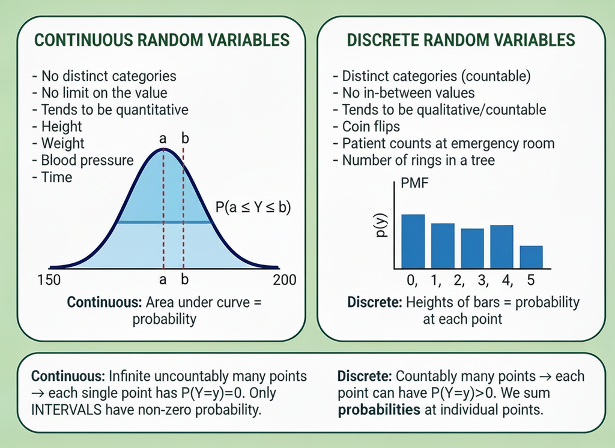

## Discrete Random Variables

- **Countable** values (often integers)
- Examples: Coin flips, patient counts at emergency room, number of rings in a tree
- Use **probability mass function (PMF)** \(p(y)\): \(P(Y = y) = p(y)\) and \(\sum_{\text{all } y} p(y) = 1\)
- **Cumulative distribution function (CDF):** \(F(y) = P(Y \leq y) = \sum_{x \leq y} p(x)\)
- Also exist quantile functions, moment generating functions, characteristic functions (beyond this course).

## Continuous Random Variables

- Values in an **interval** (uncountably many)
- Examples: Height, weight, blood pressure, time
- Use **probability density function (PDF)** \(f(y)\)
- Probabilities: \(P(a \leq Y \leq b) = \int_a^b f(y) \, dy\) and

  \(\int_{-\infty}^{\infty} f(y) \, dy = 1\)
- **Cumulative distribution function (CDF):** \(F(y) = P(Y \leq y) = \int_{-\infty}^y f(x) \, dx\)

## CRITICAL DIFFERENCE: Single Point Probability

**CHECKPOINT: Why does P(Y = 172.5) = 0 for continuous height?**

| Property | Discrete | Continuous |
| --- | --- | --- |
| \(P(Y = y)\) | **Can be > 0** | **Always = 0** |
| Example: Fair die | \(P(Y=3) = 1/6\) | — |
| Example: Height | — | \(P(\text{height}=172.5)=0\) |
| How to find probability | Use \(P(Y=y)\) | Use \(P(a \leq Y \leq b)\) |

**Intuition:** Continuous distributions have *uncountably many* points (infinity!), so each single point contributes zero probability.

Only **intervals with area** have non-zero probability.

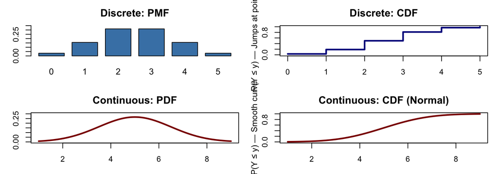

**Key insight:** PMF and PDF describe probability distributions; CDF accumulates probabilities up to a point.

## Part 2: Probability Distributions

## Probability Density Function (Continuous)

For a **continuous** \(Y\) with density \(f(y)\):

\[f(y) \geq 0 \quad \text{for all } y \quad ; \quad \int_{-\infty}^{\infty} f(y) \, dy = 1\]

For any interval \([a, b]\): \[P(a \leq Y \leq b) = \int_{a}^{b} f(y) \, dy \quad \text{(shaded area below)}\]

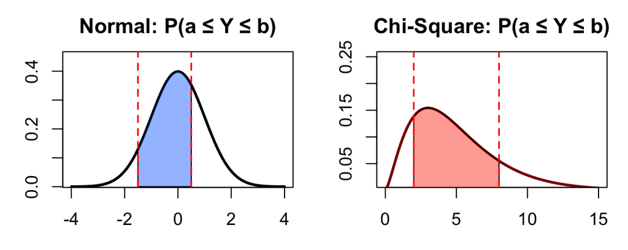

**Key insight:** Probability = area under density curve!

## Part 3: Expectation and Variance

## Expectation: Discrete Case

For a **discrete** \(Y\) with probabilities \(p(y)\):

\[E(Y) = \mu = \sum_{\text{all } y} y \cdot p(y)\]

**Fair die example** (\(\{1,2,3,4,5,6\}\), each with \(p(y) = 1/6\)): \[E(Y) = 1 \cdot \frac{1}{6} + 2 \cdot \frac{1}{6} + \cdots + 6 \cdot \frac{1}{6} = 3.5\]

**Interpretation:** Long-run average over many rolls.

## CHECKPOINT: Understanding E(Y) for the Fair Die

**Question:** Why is \(E(Y) = 3.5\), not 3 or 4? What does 3.5 mean?

- Is 3.5 a possible outcome when rolling a die? **NO**
- Does it mean we expect to see 3.5 on the next roll? **NO**
- Does it mean over 1,000 rolls, the average is *approximately* 3.5? **YES**

**Key insight:** \(E(Y)\) is the **balance point** of the distribution. Imagine the die outcomes as weights on a seesaw—3.5 is where it balances!

## Expectation: Continuous Case

For a **continuous** \(Y\) with density \(f(y)\):

\[E(Y) = \mu = \int_{-\infty}^{\infty} y \, f(y) \, dy\]

**Interpretation:** Center of mass (balance point) of the distribution.

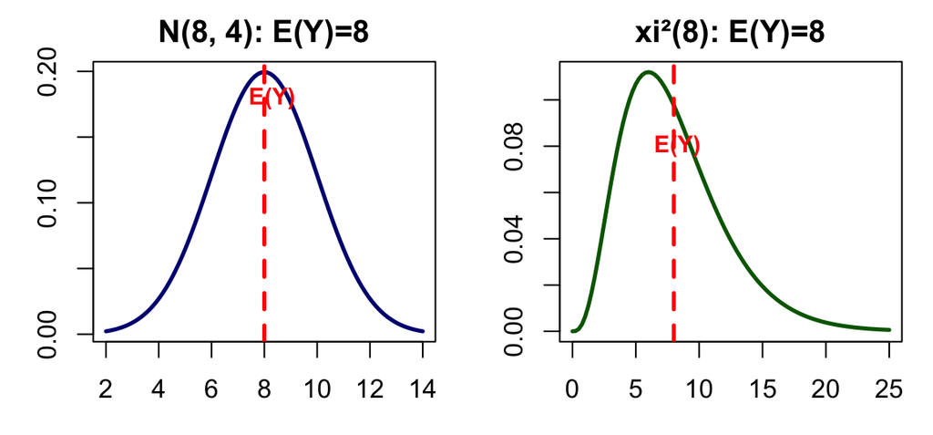

## Variance: Discrete Case

For a **discrete** \(Y\):

\[Var(Y) = \sigma^2 = E((y-\mu)^2) = \sum_{\text{all } y} (y - \mu)^2 \cdot p(y)\]

**Fair die with** \(\mu = 3.5\): \[Var(Y) = (1-3.5)^2 \cdot \frac{1}{6} + \cdots + (6-3.5)^2 \cdot \frac{1}{6} \approx 2.92\]

## Variance: Continuous Case

For a **continuous** \(Y\):

\[Var(Y) = \sigma^2 = \int_{-\infty}^{\infty} (y - \mu)^2 f(y) \, dy\]

**Standard deviation:** \(\sigma = \sqrt{Var(Y)}\) (same units as \(Y\))

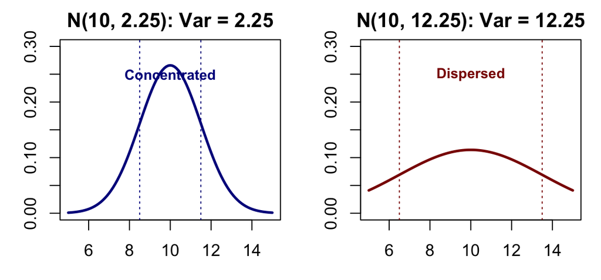

**Larger variance = more spread!**

## CHECKPOINT: Practical Variance Interpretation

**Question:** Which is less risky: Stock A with \(\sigma^2 = 4\) or Stock B with \(\sigma^2 = 16\)?

- Stock A: \(\sigma = 2\) (tightly concentrated returns)?
- Stock B: \(\sigma = 4\) (widely dispersed returns)?

**Key lesson:** Variance = **spread of outcomes**. Smaller variance = more predictable!

## Part 4: Sample Statistics

## Sample Mean and Standard Deviation

Given \(n\) observations \(y_1, \ldots, y_n\):

**Sample mean** (estimates \(\mu\)): \[\bar{y} = \frac{1}{n} \sum_{t=1}^n y_t\]

**Sample standard deviation** (estimates \(\sigma\)): \[s = \sqrt{\frac{1}{n-1} \sum_{t=1}^n (y_t - \bar{y})^2}\]

We divide by \((n-1)\) for unbiased variance estimation (**Bessel’s correction**).

## Part 5: Rules for Transformations

## Linear Transformations: \(E(cY)\) and \(Var(cY)\)

For constant \(c\) and random variable \(Y\):

\[E(c) = c, \] \[E(cY) = c \cdot E(Y)\] \[Var(c) = 0,\] \[ Var(cY) = c^2 \cdot Var(Y)\]

**Key insight:** Variance scales with \(c^2\). Doubling a variable multiplies variance by 4!

## CHECKPOINT: can someone say how to prove Var(cY) = c²Var(Y), not cVar(Y)?

**Question:** If we triple the values (multiply by 3), variance multiplies by 9. Why the square?

## Sums of Independent Variables

For independent \(Y_1, \ldots, Y_n\) with expectations \(\mu_i\) and variances \(\sigma_i^2\) and some constants $c_i$:

**Expectation of sum:** \[E\left(\sum_{i=1}^n c_iY_i\right) = \sum_{i=1}^n c_i\mu_i\]

**Variance of sum (independent only):** \[Var\left(\sum_{i=1}^n c_iY_i\right) = \sum_{i=1}^n c_i^2\sigma_i^2\]

## Part 6: Key Distributions

## The Normal Distribution

**Notation:** \(Y \sim N(\mu, \sigma^2)\)

**PDF:** \(f(y) = \frac{1}{\sigma\sqrt{2\pi}} \exp\left\{-\frac{1}{2}\left(\frac{y-\mu}{\sigma}\right)^2\right\}\)

**Empirical Rule & Visual:**

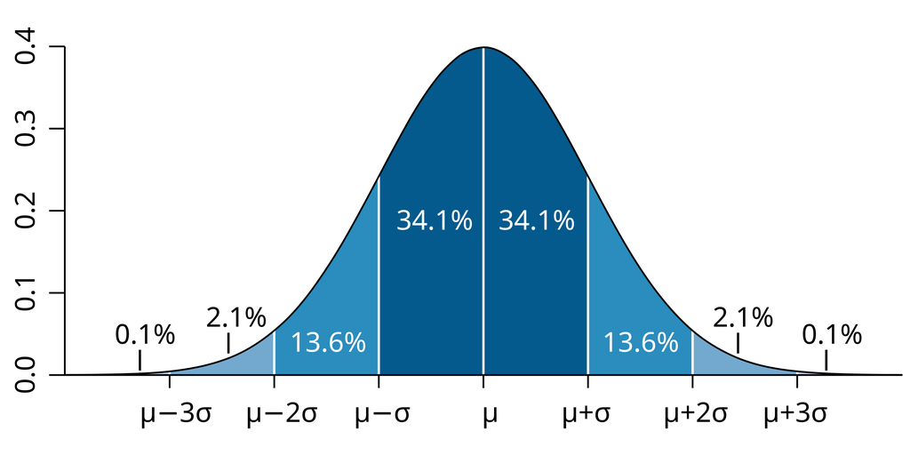

## CHECKPOINT: SAT Scores and the 68-95 Rule

**Application:** SAT scores follow \(N(\mu=500, \sigma=100)\).

- What % score between **400-600**? (within 1 standard deviation)
- What % score between **300-700**? (2 standard deviations away from mean)

## CHECKPOINT: SAT Scores and the 68-95 Rule

**Application:** SAT scores follow \(N(\mu=500, \sigma=100)\).

- What % score between **400-600**? (within 1 standard deviation)
  - **Answer: 68.2%**
- What % score between **300-700**? (2 standard deviations away from mean)
  - **Answer: 95.4%**

**Why this matters:** Standardized tests are designed using normal distributions. Knowing the 68-95 rule helps interpret scores!

## Carl Friedrich Gauss (1777–1855)

**The “Prince of Mathematicians”** and namesake of the normal distribution.

- Developed the **normal distribution** and **method of least squares** (circa 1809!)
- Used statistics to model astronomical observations, revolutionizing scientific practice
- Discovered that many natural measurements follow the bell-shaped curve

**Legacy:** The normal distribution is also called the **Gaussian distribution** in his honor

## Linear Combinations of Normal Variables

If \(Y_1 \sim N(\mu_1, \sigma_1^2)\) and \(Y_2 \sim N(\mu_2, \sigma_2^2)\) are *independent*:

\[aY_1 + bY_2 \sim N(a\mu_1 + b\mu_2, \, a^2\sigma_1^2 + b^2\sigma_2^2)\]

This is **fundamental** for inference about sample means and regression.

## The Chi-Square Distribution

**Notation:** \(Y \sim \chi^2_k\) where \(k\) = degrees of freedom

**Key derivation:** \(Z^2 \sim \chi^2_1\) if \(Z \sim N(0,1)\); additive property: \(\sum_{i=1}^k Z_i^2 \sim \chi^2_k\)

**Properties:** \(E(Y) = k\), \(Var(Y) = 2k\)

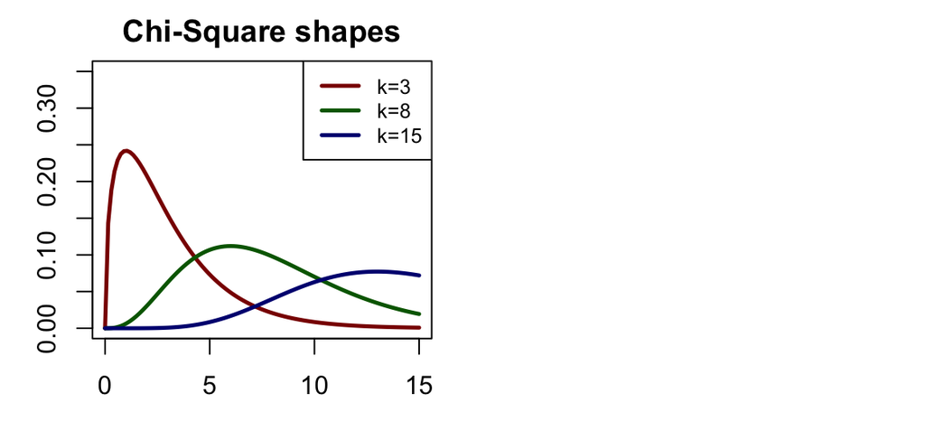

## The Student’s \(t\) Distribution

**Definition:** For independent \(Z \sim N(0,1)\) and \(\chi^2_k\):

\[T = \frac{Z}{\sqrt{\chi^2_k / k}} \sim t_k\]

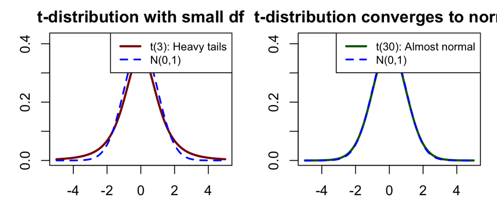

**Properties:** Symmetric, heavier tails than normal, converges to \(N(0,1)\) as \(k \to \infty\)

## William Sealy Gosset (1876–1937): “Student”

- Faced a practical problem: small sample inference for quality control
- Published under the pseudonym **“Student”** because Guinness forbade employee publications

## The \(t\) Distribution: Practical Use

**Test statistic for population mean:**

If \(Y_1, \ldots, Y_n\) i.i.d. \(N(\mu, \sigma^2)\) and \(S^2 = \frac{1}{n-1}\sum_{t=1}^n (Y_t - \bar{Y})^2\):

\[T = \frac{\bar{Y} - \mu}{\sqrt{S^2/n}} \sim t_{n-1}\]

This is the **one-sample** \(t\) test statistic.

## Ronald Aylmer Fisher (1890–1962)

- Invented the **F distribution**, **ANOVA** (analysis of variance), and **maximum likelihood estimation**
- Pioneered **experimental design** principles (randomization, blocking, replication)
- Won the prestigious **Weldon Medal** for his contributions to statistical science

**Legacy:** Fisher’s work transformed statistics from a descriptive tool to a framework for scientific inference.

## The \(F\) Distribution

**Notation:** \(Y \sim F_{u,v}\) where \(u, v\) = degrees of freedom

**Definition:** For independent \(\chi^2_u\) and \(\chi^2_v\):

\[F = \frac{\chi^2_u / u}{\chi^2_v / v} \sim F_{u,v}\]

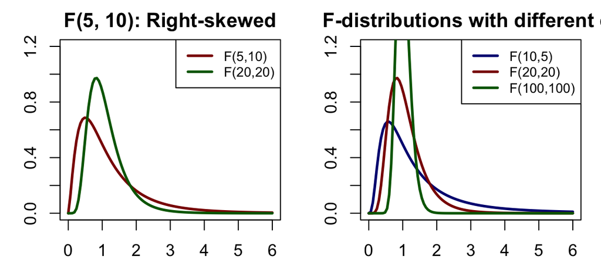

Used for ANOVA and comparing variances (Fisher’s major contributions).

## Many more distributions of course

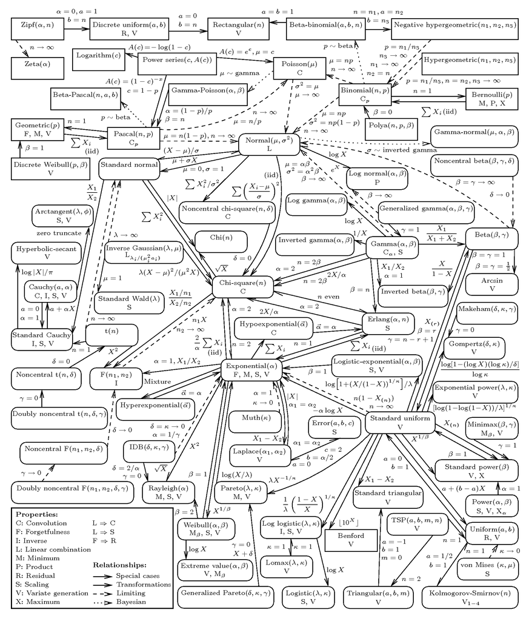